# Practical Machine Learning Project

## Summary

The goal of this project is to predict the manner in which the exercises were performed by different subjects.

This is the “classe” variable in the training set. You may use any of the other variables to predict with.

## How the model is built

To create a model, I first performed an explanatory analysis of the data.

```r
trainProj<-read.csv("pml-training.csv", na.strings= c("NA", " ", ""))
dim(trainProj)
```

```
## [1] 19622   160
```

```r
isNA<-colSums(is.na(trainProj))
isNotNA<-isNA[isNA==0]
trainNotNA<-trainProj[names(isNotNA)]
trainSet<-trainNotNA[,-c(1:7)]
```

The analysis showed that there are 100 variables with 19,216 missing values in each column, out of 19622. With 97.93% of the data missing for these variables, these variables were removed as predictors. The variables related to time and users (columns 1 to 7) were also removed as predictors, since they do not add information about the performance of an activity.

The new training set has 53 variables.

# Training the model on training set

I have used random forest algorithm with 10-fold cross validation method, repeated 3 times when training the machine learning algorithm.

```r
library(caret)
control <- trainControl(method="repeatedcv", number=10, repeats=3)
seed <- 555
metric <- "Accuracy"
```

I then used tuneRF function in randomForest package to find the best value for mtry that gives the smallest OOB error.

```r
library(randomForest)
library(dplyr)
require(fastmatch)
n<-fmatch("classe",names(trainSet))
x<-trainSet[,-n]
y<-trainSet[,n]
set.seed(seed)
bestmtry <- tuneRF(x, y, stepFactor=1.5, improve=1e-5, ntree=500)
```

```
## mtry = 7  OOB error = 0.3%
## Searching left ...
## mtry = 5     OOB error = 0.3%
## 0.01694915 1e-05
## mtry = 4     OOB error = 0.31%
## -0.03448276 1e-05
## Searching right ...
## mtry = 10    OOB error = 0.25%
## 0.137931 1e-05
## mtry = 15    OOB error = 0.31%
## -0.2 1e-05
```

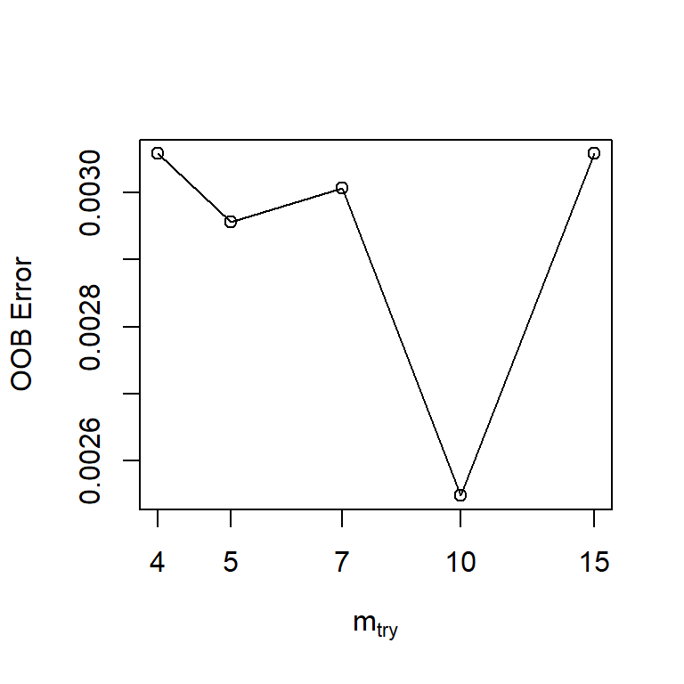

```r
print(bestmtry)
```

```
##        mtry    OOBError
## 4.OOB     4 0.003057792
## 5.OOB     5 0.002955866
## 7.OOB     7 0.003006829
## 10.OOB   10 0.002548160
## 15.OOB   15 0.003057792
```

mtry = 10 gives the minimun OOB error = 0.0025482.

I then trained the model with this value of mtry.

```r
set.seed(seed)
mtry <- bestmtry[which(bestmtry[,2]==min(bestmtry[,2])),1]
tunegrid <- expand.grid(.mtry=mtry)
rfModel <- train(x, y, data=trainSet, method="rf", metric=metric, tuneGrid=tunegrid, trControl=control)
print(rfModel)
```

```
## Random Forest
##
## 19622 samples
##    52 predictor
##     5 classes: 'A', 'B', 'C', 'D', 'E'
##
## No pre-processing
## Resampling: Cross-Validated (10 fold, repeated 3 times)
## Summary of sample sizes: 17660, 17660, 17660, 17660, 17658, 17661, ...
## Resampling results:
##
##   Accuracy   Kappa
##   0.9968062  0.9959599
##
## Tuning parameter 'mtry' was held constant at a value of 10
```

```r
print(rfModel$finalModel)
```

```
##
## Call:
##  randomForest(x = x, y = y, mtry = param$mtry, data = ..1)
##                Type of random forest: classification
##                      Number of trees: 500
## No. of variables tried at each split: 10
##
##         OOB estimate of  error rate: 0.3%
## Confusion matrix:
##      A    B    C    D    E  class.error
## A 5578    1    0    0    1 0.0003584229
## B   10 3783    4    0    0 0.0036871214
## C    0    9 3409    4    0 0.0037989480
## D    0    0   22 3192    2 0.0074626866
## E    0    0    1    4 3602 0.0013861935
```

Calculating OOB:

```r
computeOOBErrEst <- function (x)
{
  cm <- x$confusion
  cm <- cm[, -ncol(cm)]
  1 - sum(diag(cm)) / sum(cm)
}
rfOOB<-computeOOBErrEst(rfModel$finalModel)
```

Now test the model on the test set. First, transform the test set to get the same predictors used in training the model.

```r
testProj<-read.csv("pml-testing.csv", na.strings= c("NA", " ", ""))
testSet<-testProj[names(x)]
predictions<-predict(rfModel,newdata = testSet)
```

# Out-of-sample error